# Correlation and Regression

Connor Guest

6/6/2019

Ultimately data analysis is about understanding the relationship between two variables.

Statistical models have one variable as the output (response variable, y, aka dependent) and one or more as the input (explannatory variable, x, independent).

```r
library(openintro)
library(ggplot2)
library(knitr)
library(dplyr)
library(ggthemes)
library(readr)
library(tidyr)
```

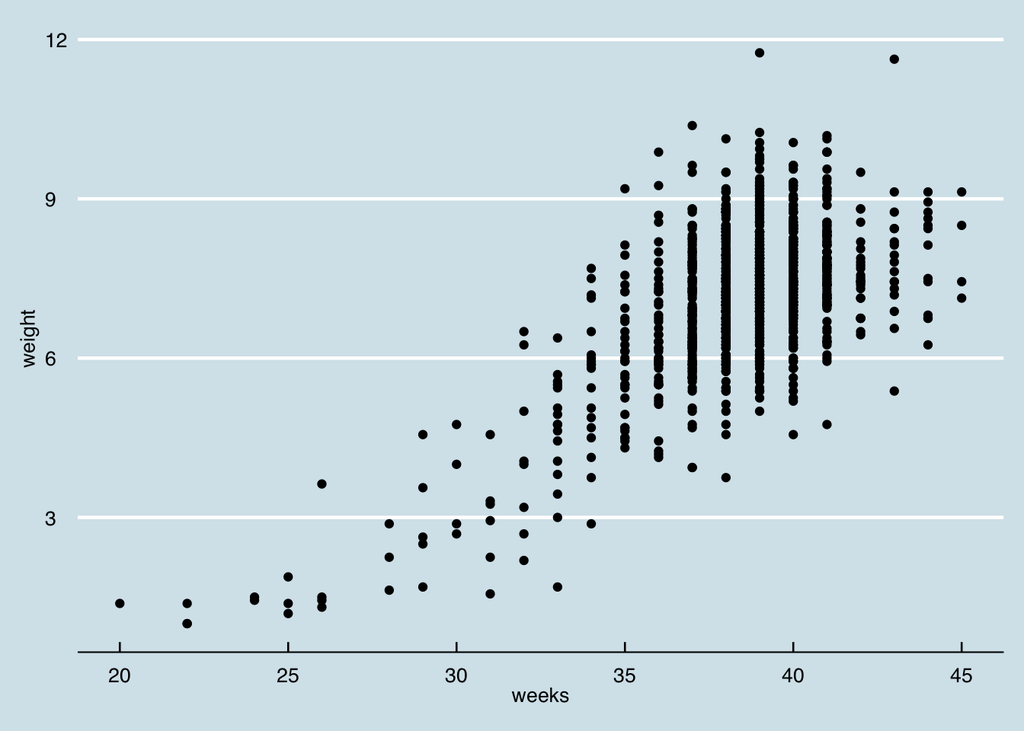

```r
data(ncbirths)

# Scatterplot of weight vs. weeks
ncbirths %>%
  ggplot(aes(x = weeks, y = weight)) +
  geom_point() +
  theme_economist()
```

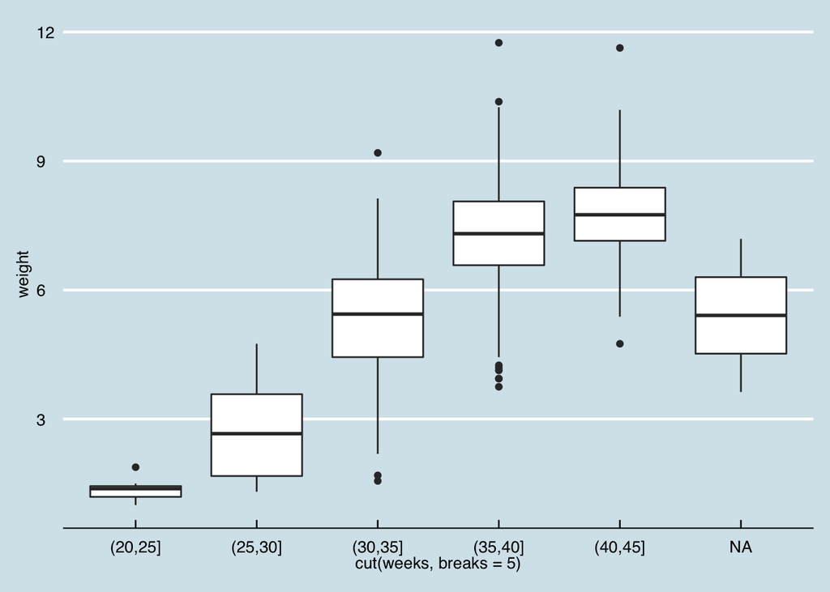

```r
# Boxplot of weight vs. weeks
ggplot(data = ncbirths,
       aes(x = cut(weeks, breaks = 5), y = weight)) +
  geom_boxplot() +
  theme_economist()
```

look for:  
form - linear, quadratic, non-linear  
direction - postive or negative, do they variables go up together? strength - how much scatter / noise outliers - these can be revealing when analysing a relationship between variables

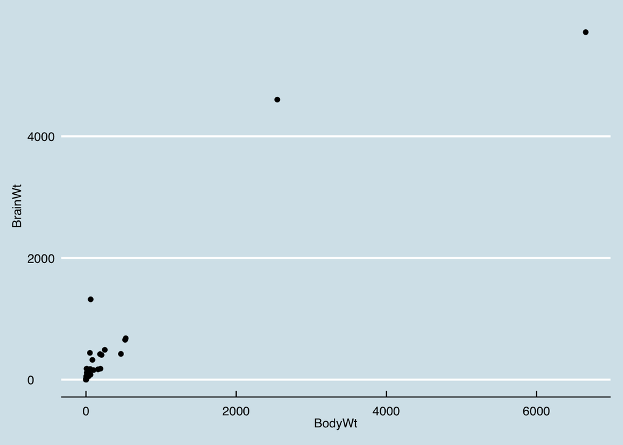

```r
# Mammals scatterplot
ggplot(data = mammals,
       aes(x = BodyWt, y = BrainWt)) +
  geom_point() +
  theme_economist()
```

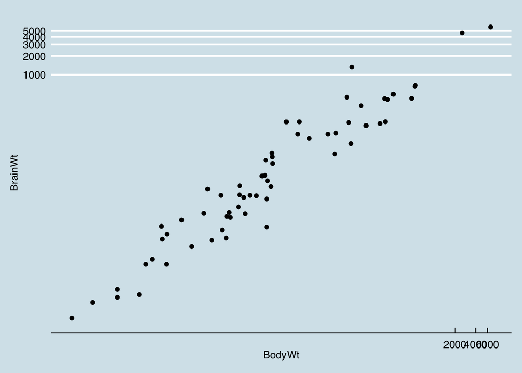

```r
# Scatterplot with coord_trans()
ggplot(data = mammals, aes(x = BodyWt, y = BrainWt)) +
  geom_point() +
  coord_trans(x = "log10", y = "log10") +
  theme_economist()
```

```r
# Correlation among mammals, with and without log
mammals %>%
  summarize(N = n(),
            r = cor(BodyWt, BrainWt),
            r_log = cor(log(BodyWt), log(BrainWt)))
```

| N | r | r_log |
| --- | --- | --- |
| 62 | 0.9341638 | 0.9595748 |

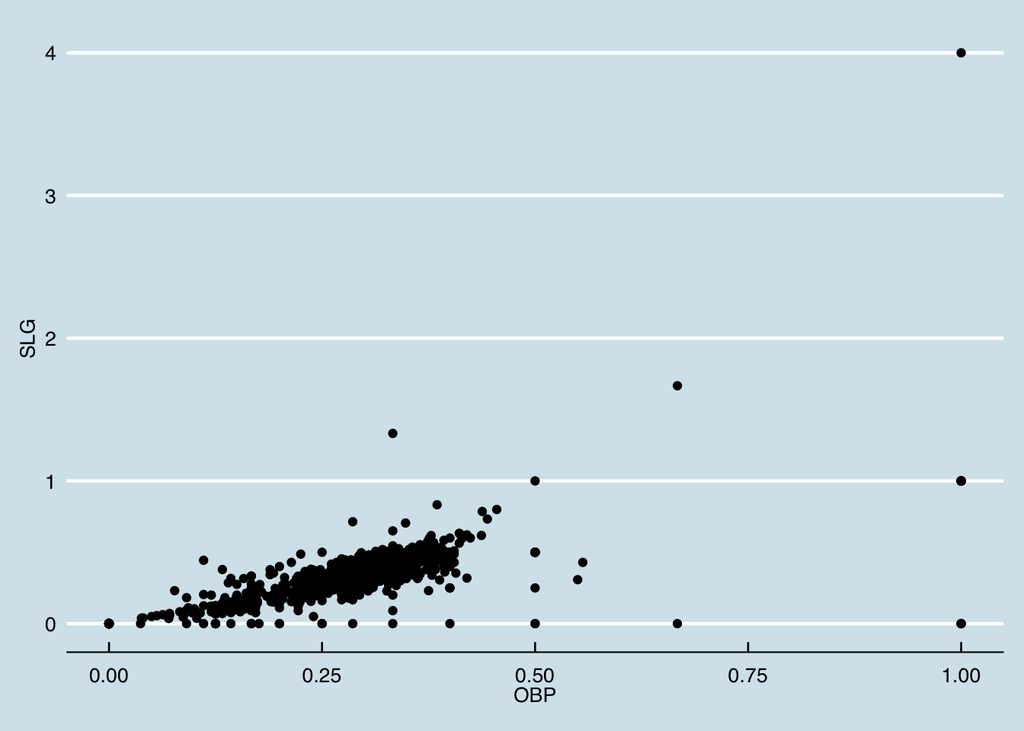

```r
# Baseball player scatterplot
ggplot(data = mlbBat10,
       aes(x = OBP, y = SLG)) +
  geom_point() +
  theme_economist()
```

```r
# Correlation for all baseball players
mlbBat10 %>%
  summarize(N = n(), r = cor(OBP, SLG))
```

| N | r |
| --- | --- |
| 1199 | 0.8145628 |

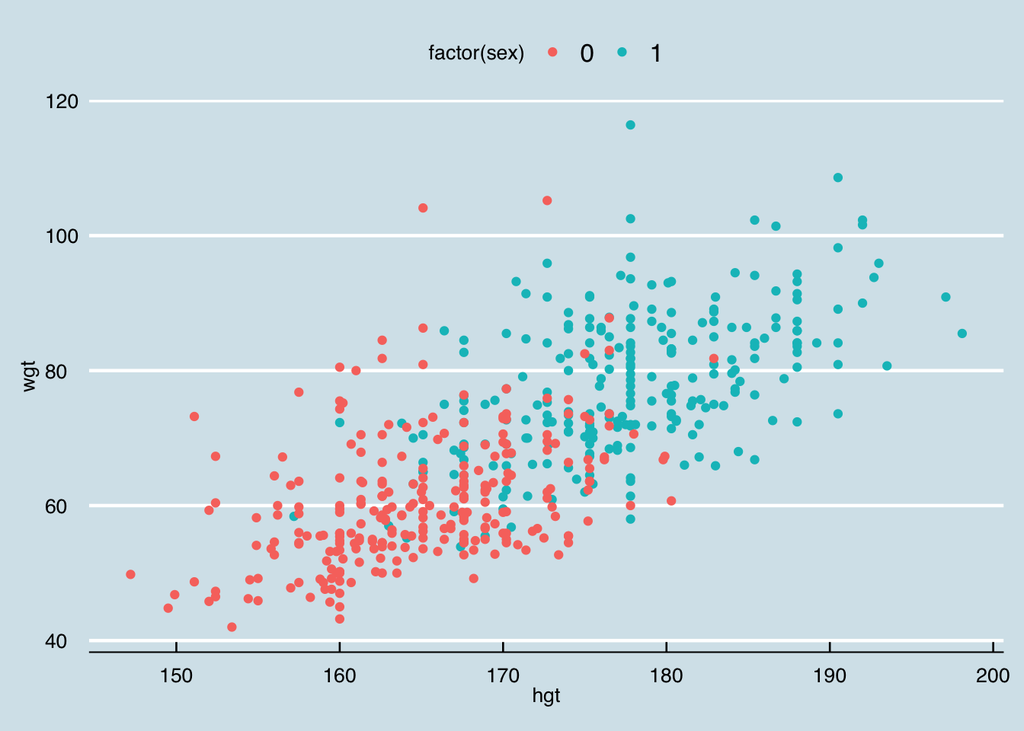

```r
# Body dimensions scatterplot
ggplot(data = bdims,
       aes(x = hgt, y = wgt, color = factor(sex))) +
  geom_point() +
  theme_economist()
```

```r
# Correlation of body dimensions
bdims %>%
  group_by(sex) %>%
  summarize(N = n(), r = cor(wgt, hgt))
```

| sex | N | r |
| --- | --- | --- |
| 0 | 260 | 0.4310593 |
| 1 | 247 | 0.5347418 |

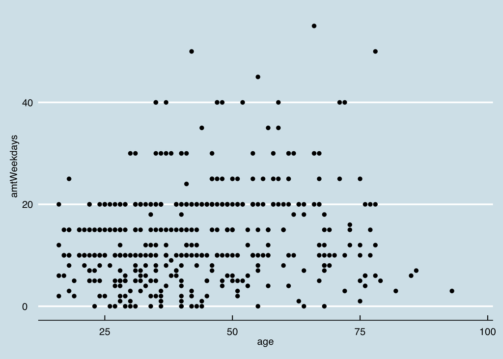

```r
# Smoking scatterplot
ggplot(data = smoking,
       aes(x = age, y = amtWeekdays)) +
  geom_point() +
  theme_economist()
```

changing coordinates

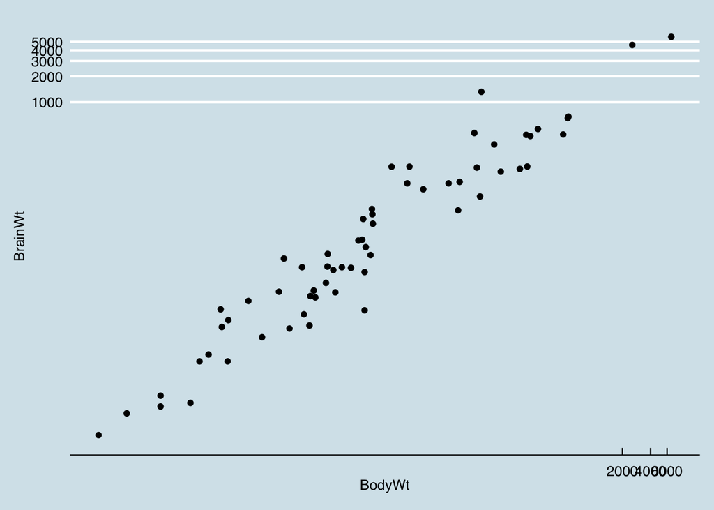

```r
# Scatterplot with coord_trans()
ggplot(data = mammals, aes(x = BodyWt, y = BrainWt)) +
  geom_point() +
  coord_trans(x = "log10", y = "log10") +
  theme_economist()
```

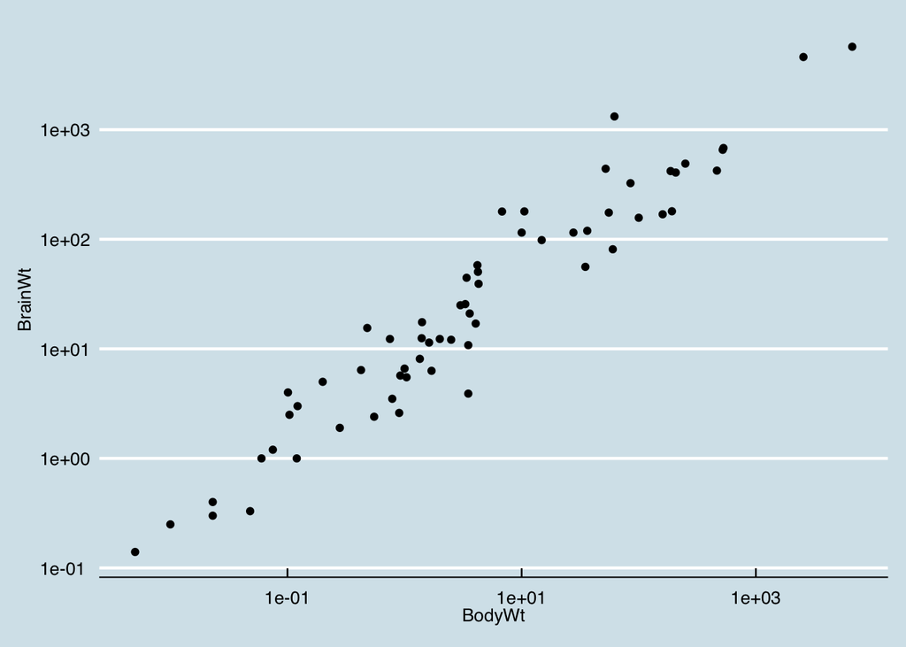

```r
# Scatterplot with scale_x_log10() and scale_y_log10()
ggplot(data = mammals, aes(x = BodyWt, y = BrainWt)) +
  geom_point() +
  scale_x_log10() + scale_y_log10() +
  theme_economist()
```

Dealing with outliers You can add geom_point(alpha = .5) to reduce the transparency of the points so you can see where points are on top of eachother geom_point(postion = “jitter”) which gives some random noise to the points

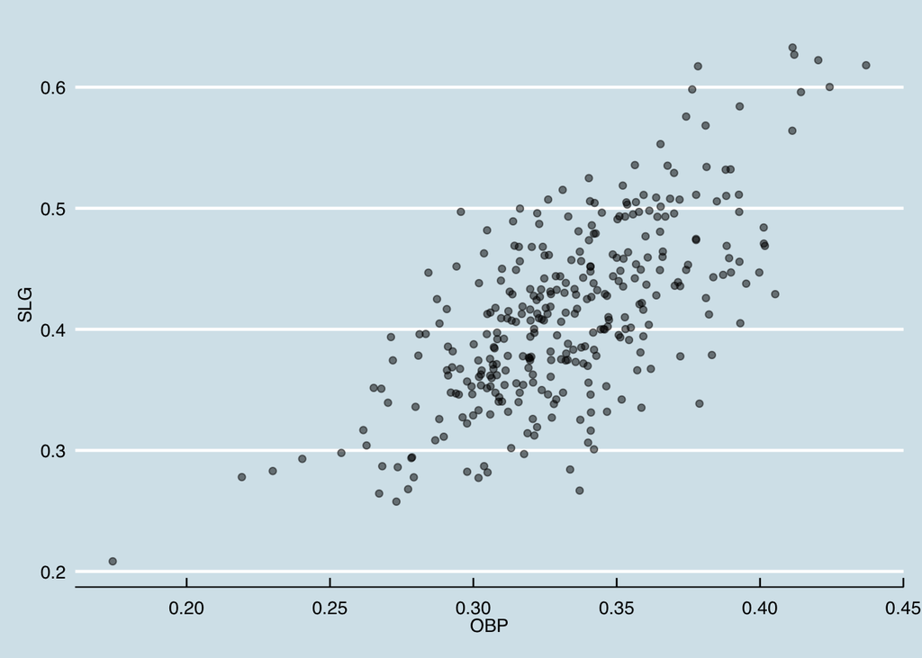

```r
# Scatterplot of SLG vs. OBP
mlbBat10 %>%
  filter(AB >= 200) %>%
  ggplot(aes(x = OBP, y = SLG)) +
  geom_point(alpha=.5, position="jitter") + theme_economist()
```

```r
# Identify the outlying player
mlbBat10 %>%
  filter(AB >= 200, OBP < 0.2)
```

| name | team | position | G | AB | R | H | 2B | 3B | HR | RBI | TB | BB | SO | SB | CS | OBP | SLG | AVG |
| --- | --- | --- | --- | --- | --- | --- | --- | --- | --- | --- | --- | --- | --- | --- | --- | --- | --- | --- |
| B Wood | LAA | 3B | 81 | 226 | 20 | 33 | 2 | 0 | 4 | 14 | 47 | 6 | 71 | 1 | 0 | 0.174 | 0.208 | 0.146 |

```r
# Correlation for all players with at least 200 ABs
mlbBat10 %>%
  filter(AB >= 200) %>%
  summarize(N = n(), r = cor(OBP, SLG))
```

| N | r |
| --- | --- |
| 329 | 0.6855364 |

Correlation - quantifying the strenght of a **linear** realtionship - doesnt quantify relationships for non-linear relationships Correlation coef is between -1 and 1 Sign is the direction close to 1 is near perfect correlation is most often defined by the **pearson product moment correlation**